# Netværksgraf 3 med vægte og karakterer, som ikke taler, men er til stede

# Find Nodes and Edges and combine with weights

Finde vægte til kanter. Der er en kant mellem 2 personer, hvis de begge to har haft en replik i samme scene. vægten på den kant er antallet af ord sagt i den scene. Hvis to personer har talt sammen i flere scener, lægger vi antallet af ord sagt i hver af scenerne sammen, og det er så vægten på kanten. Jeg havde en fejl med antallet af kanter, men den tror jeg, jeg har fikset nu. Så er næste spørgsmål om jeg så har regnet vægtene rigtigt - og om det ikke kan skrives lidt mere læseligt.

Disse kanter er i princippet uden retning eller i begge retninger.

```r
# find nodes using function
(speakers2nodes(distinct_speakers) -> nodes_play)
```

| id | speaker |
| --- | --- |
| 1 | henrik |
| 2 | pernille |
| 3 | leonard |
| 4 | leonora |
| 5 | gunild |
| 6 | gilbert |
| 7 | mester gert westphaler |
| 8 | svenden |
| 9 | jesper |
| 10 | tobias |

[output cut: 2 more lines]

```r
# find edges and combine edges with weights
# (trouble when finding the edges using the function,
# we discarded act and scene;
# lets try finding them here instead)

#create column 'speaker2' and make it equal to 'speaker' (duplicate).
distinct_speakers$speaker2 = distinct_speakers$speaker

# All possible combinations (remember the data is still grouped by act-number and scene-number)
distinct_speakers %>%
    expand(speaker, speaker2) %>%
    # fjern selvreferencer
    filter(speaker != speaker2) -> who_speaks_to_whom

(who_speaks_to_whom  %>%
      ungroup() %>%
      # fjern kant i den ene retning for ikke at tælle dobbelt
      filter(speaker < speaker2) %>%
      select(from = speaker, to = speaker2) %>%
      distinct() -> edges_play)
```

| from | to |
| --- | --- |
| henrik | pernille |
| henrik | leonard |
| leonard | pernille |
| leonard | leonora |
| leonora | pernille |
| gilbert | gunild |
| gunild | mester gert westphaler |
| mester gert westphaler | svenden |
| jesper | mester gert westphaler |
| leonora | mester gert westphaler |

[output cut: 12 more lines]

```r
# Kombiner med vægte
(who_speaks_to_whom %>% right_join(scene_weights) -> who_speaks_to_whom_with_weights)
```

| act_number | scene_number | speaker | speaker2 | words | act | scene |
| --- | --- | --- | --- | --- | --- | --- |
| 1 | 1 | henrik | pernille | 865 | [Tekst] | Scene 1 |
| 1 | 1 | pernille | henrik | 865 | [Tekst] | Scene 1 |
| 1 | 2 | henrik | leonard | 203 | [Tekst] | Scene 2 |
| 1 | 2 | henrik | pernille | 203 | [Tekst] | Scene 2 |
| 1 | 2 | leonard | henrik | 203 | [Tekst] | Scene 2 |
| 1 | 2 | leonard | pernille | 203 | [Tekst] | Scene 2 |
| 1 | 2 | pernille | henrik | 203 | [Tekst] | Scene 2 |
| 1 | 2 | pernille | leonard | 203 | [Tekst] | Scene 2 |
| 1 | 3 | leonard | leonora | 92 | [Tekst] | Scene 3 |
| 1 | 3 | leonora | leonard | 92 | [Tekst] | Scene 3 |

[output cut: 63 more lines]

```r
# Opsumér vægte
(who_speaks_to_whom_with_weights  %>%
    ungroup() %>%
    rename(from=speaker, to=speaker2) %>%
    select(from,to,words) %>%
    filter(!is.na(to)) %>%
    group_by(from,to) %>%
    arrange(from,to,words) %>%
    mutate(weight=sum(words)) %>%
    ungroup() %>%
    select(from,to,weight) %>%
      filter(from < to) %>% # fjern kant i den ene retning
    distinct() -> edges_weights)
```

| from | to | weight |
| --- | --- | --- |
| gilbert | gottard | 1039 |
| gilbert | gunild | 1058 |
| gilbert | leonora | 1039 |
| gilbert | mester gert westphaler | 1039 |
| gilbert | pernille | 1266 |
| gottard | leonard | 201 |
| gottard | leonora | 1240 |
| gottard | mester gert westphaler | 1039 |
| gottard | pernille | 1039 |
| gunild | leonora | 230 |

[output cut: 12 more lines]

```r
# ungroup,rename,select,filter are just data wrangling
# We group by from,to.
# Arrange is just for display purposes
# Mutate weight=sum(words) sums in each group
# We can then ungroup
# select removes unnessesary columns
# distinct ensures that each edge exists just once
```

# Draw first graph

We can now draw a graph with weighted edges like this.

```r
nodes_play
```

| id | speaker |
| --- | --- |
| 1 | henrik |
| 2 | pernille |
| 3 | leonard |
| 4 | leonora |
| 5 | gunild |
| 6 | gilbert |
| 7 | mester gert westphaler |
| 8 | svenden |
| 9 | jesper |
| 10 | tobias |

[output cut: 2 more lines]

```r
edges_weights
```

| from | to | weight |
| --- | --- | --- |
| gilbert | gottard | 1039 |
| gilbert | gunild | 1058 |
| gilbert | leonora | 1039 |
| gilbert | mester gert westphaler | 1039 |
| gilbert | pernille | 1266 |
| gottard | leonard | 201 |
| gottard | leonora | 1240 |
| gottard | mester gert westphaler | 1039 |
| gottard | pernille | 1039 |
| gunild | leonora | 230 |

[output cut: 12 more lines]

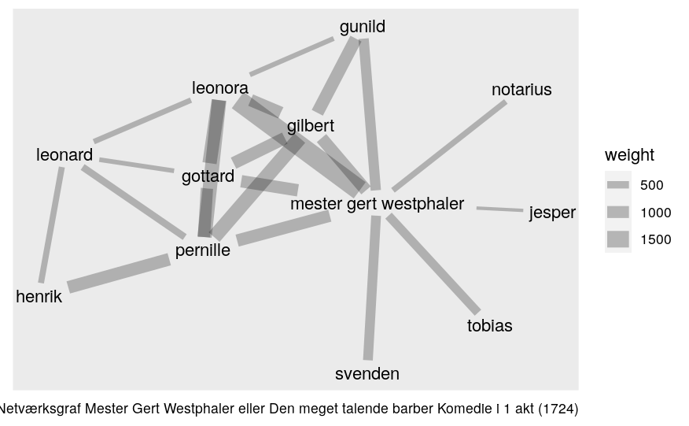

```r
gr1 <- tbl_graph(nodes = nodes_play, edges = edges_weights, directed = FALSE, node_key = "speaker")

(ggraph(gr1, layout = 'stress') +
    geom_edge_link(aes(start_cap = label_rect(node1.speaker),
                       end_cap = label_rect(node2.speaker),
                       width = weight
                       ),
                   alpha = .25) +
    geom_node_text(aes(label = speaker)) +
    labs(caption = paste("Netværksgraf", my_title, my_year)))

ggsave(here("graphs/netvaerksgraf3", paste(my_file, ".no-arrows.no-silent-characters.stress.png")))
```

# Find the characters that are present but do not speak

Så vil vi prøve at tilføje stumme karakterer med en anden farve kanter kanter.

Disse kanter har en retning fra “den stumme karakter” til dem der taler!

```r
(present_without_speech(play) -> present_but_silent)
```

| act | scene | index | word |
| --- | --- | --- | --- |
| [Tekst] | Scene 25 | 46 | leonard |

```r
# Her skal vi også have sat vægte på
# Det kan vi gøre ud fra act_number og scene_number igen
(present_but_silent %>% left_join(scene_weights) %>%
    distinct() -> present_but_silent_with_weights)
```

| act | scene | index | word | act_number | scene_number | words | speaker |
| --- | --- | --- | --- | --- | --- | --- | --- |
| [Tekst] | Scene 25 | 46 | leonard | 1 | 25 | 1039 | mester gert westphaler |
| [Tekst] | Scene 25 | 46 | leonard | 1 | 25 | 1039 | leonora |
| [Tekst] | Scene 25 | 46 | leonard | 1 | 25 | 1039 | gottard |
| [Tekst] | Scene 25 | 46 | leonard | 1 | 25 | 1039 | pernille |
| [Tekst] | Scene 25 | 46 | leonard | 1 | 25 | 1039 | gilbert |

```r
# combine with speakers by act and scene and rename
(present_but_silent_with_weights %>%
    rename(from=word, to=speaker) %>%
  select(from,to,words) %>%
  filter(!is.na(to)) %>%
  group_by(from,to) %>%
  arrange(from,to,words) %>%
    distinct() %>%
  mutate(weight=sum(words)) -> tmp)
```

| from | to | words | weight |
| --- | --- | --- | --- |
| leonard | gilbert | 1039 | 1039 |
| leonard | gottard | 1039 | 1039 |
| leonard | leonora | 1039 | 1039 |
| leonard | mester gert westphaler | 1039 | 1039 |
| leonard | pernille | 1039 | 1039 |

```r
(tmp %>%
  ungroup() %>%
  select(from,to,weight) %>%
  distinct() -> silent_edges_with_weights)
```

| from | to | weight |
| --- | --- | --- |
| leonard | gilbert | 1039 |
| leonard | gottard | 1039 |
| leonard | leonora | 1039 |
| leonard | mester gert westphaler | 1039 |
| leonard | pernille | 1039 |

```r
NA
NA
```

# Draw second graph

We can now combine the two sets of weighted edges and draw a graph like this.

```r
edges_weights$type = "speaking"

silent_edges_with_weights$type = "silent"

(silent_edges_with_weights %>% bind_rows(edges_weights) -> edges_combined)
```

| from | to | weight | type |
| --- | --- | --- | --- |
| leonard | gilbert | 1039 | silent |
| leonard | gottard | 1039 | silent |
| leonard | leonora | 1039 | silent |
| leonard | mester gert westphaler | 1039 | silent |
| leonard | pernille | 1039 | silent |
| gilbert | gottard | 1039 | speaking |
| gilbert | gunild | 1058 | speaking |
| gilbert | leonora | 1039 | speaking |
| gilbert | mester gert westphaler | 1039 | speaking |
| gilbert | pernille | 1266 | speaking |

[output cut: 17 more lines]

```r
nodes_play
```

| id | speaker |
| --- | --- |
| 1 | henrik |
| 2 | pernille |
| 3 | leonard |
| 4 | leonora |
| 5 | gunild |
| 6 | gilbert |
| 7 | mester gert westphaler |
| 8 | svenden |
| 9 | jesper |
| 10 | tobias |

[output cut: 2 more lines]

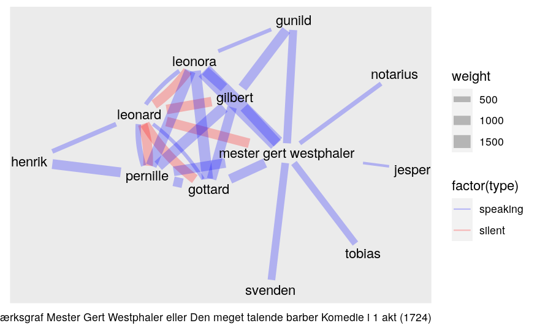

```r
gr1 <- tbl_graph(nodes = nodes_play, edges = edges_combined, directed = TRUE, node_key = "speaker")

# gr1 %>% activate(edges) # test

ggraph(gr1, layout = 'stress') + # prøv med forskellige layouts
                                 # muligheder: 'stress' 'dh' 'drl' 'fr' 'gem' 'graphopt' 'kk' 'lgl'
                                 # 'mds''randomly' m.fl.
    scale_edge_colour_manual(values = c("speaking" = "blue", "silent" = "red")) + # bestem farver manuelt

    geom_edge_fan(aes(start_cap = label_rect(node1.speaker),
                       end_cap = label_rect(node2.speaker),
                       width = weight,
                       colour = factor(type)),
#                  arrow = arrow(length = unit(2, 'mm'), type = "closed"), # sæt pile på
                   alpha = .25) +
#    geom_node_point(aes(fill = speaker),shape = 21,size = 5) + # overvej knuder
    geom_node_text(aes(label = speaker), check_overlap = TRUE) + # prøv med og uden
                                                                               # check_overlap = TRUE, repel = TRUE
    labs(caption = paste("Netværksgraf", my_title, my_year))

# Create a PNG file for the graph (`mypng.png`)
ggsave(here("graphs/netvaerksgraf3", paste(my_file, ".no-arrows.stress.check_overlap.png")))
```

# Draw third graph

To get arrows only on the silent edges, we can try creating two graphs and joining them. The trouble is that we put the arrows on when drawing the graph… We can try drawing the edges for the speaking characters in both directions instead! Now the weights bother me!

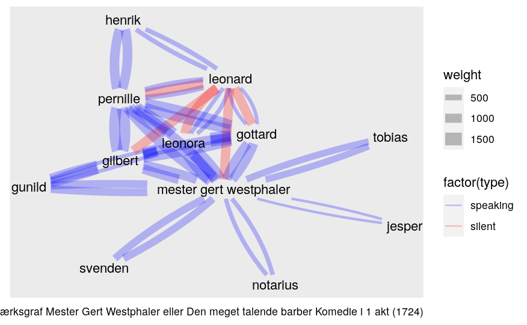

```r
gr2 <- tbl_graph(nodes = nodes_play, edges = edges_weights, directed = TRUE, node_key = "speaker")
gr3 <- tbl_graph(nodes = nodes_play, edges = silent_edges_with_weights, directed = TRUE, node_key = "speaker")
gr4 <- gr2 %>%
    mutate(graph = 'reverse') %>%
    activate(edges) %>%
    reroute(from = to, to = from)
gr4 %>% graph_join(gr3) %>% graph_join(gr2) %>%
ggraph(layout = 'lgl') + # prøv med forskellige layouts
                                 # muligheder: 'stress' 'dh' 'drl' 'fr' 'gem' 'graphopt' 'kk' 'lgl'
                                 # 'mds''randomly' m.fl.
    scale_edge_colour_manual(values = c("speaking" = "blue", "silent" = "red")) + # bestem farver manuelt

    geom_edge_fan(aes(start_cap = label_rect(node1.speaker),
                       end_cap = label_rect(node2.speaker),
                       width = weight,
                       colour = factor(type)),
#                  arrow = arrow(length = unit(2, 'mm'), type = "closed"), # sæt pile på
                   alpha = .25) +
#    geom_node_point(aes(fill = speaker),shape = 21,size = 5) + # overvej knuder
    geom_node_text(aes(label = speaker), check_overlap = TRUE) + # prøv med og uden
                                                                               # check_overlap = TRUE, repel = TRUE
    labs(caption = paste("Netværksgraf", my_title, my_year))
# Create a PNG file for the graph (`mypng.png`)
ggsave(here("graphs/netvaerksgraf3", paste(my_file, ".lgl.check_overlap.png")))
```